# Correlations

```r
aic.df <- read_csv("~/plots/all_data/aic.csv")
```

#add the replicate info

```r
aic.df <- aic.df %>%
  mutate(exp.field = paste0(str_split(cell.id, "_", simplify = T)[,2],"_",
                            str_split(cell.id, "_", simplify = T)[,3]),
    colony = case_when(exp.field %in% c("20min_s3", "20min_s4") ~ "Replicate 1",
                            exp.field %in% c("20min_s5", "20min_s6") ~ "Replicate 2",
                            exp.field %in% c("20min_s7", "20min_s8" , "20min_s9") ~ "Replicate 3"))

aic.df <- aic.df %>%
  mutate(colony = ifelse(degron == "stable" & red == "pup1-rfp",
                         case_when(exp.field %in% c("20min_s4", "20min_s5") ~ "Replicate 1",
                                   exp.field %in% c("20min_s6", "20min_s7") ~ "Replicate 2",
                                   exp.field %in% c("20min_s8", "20min_s9") ~ "Replicate 3"), colony))
  # filter(value < 0.05)
```

Cellular attributes

```r
pup1.cell.attr <- read_csv("~/plots/all_data/all_pup1_cell_attr.csv")
```

#pup1-RFP background

```r
pup1.cell.attr <- pup1.cell.attr %>%
  mutate(exp.field = paste0(str_split(cell.id, "_", simplify = T)[,2],"_",
                            str_split(cell.id, "_", simplify = T)[,3]),
    colony = case_when(exp.field %in% c("20min_s3", "20min_s4") ~ "Replicate 1",
                            exp.field %in% c("20min_s5", "20min_s6") ~ "Replicate 2",
                            exp.field %in% c("20min_s7", "20min_s8" , "20min_s9") ~ "Replicate 3"))

pup1.cell.attr <- pup1.cell.attr %>%
  mutate(colony = ifelse(degron == "stable" & red == "pup1-rfp",
                         case_when(exp.field %in% c("20min_s4", "20min_s5") ~ "Replicate 1",
                                   exp.field %in% c("20min_s6", "20min_s7") ~ "Replicate 2",
                                   exp.field %in% c("20min_s8", "20min_s9") ~ "Replicate 3"), colony))
```

```r
# dy.pup1.rep1.all <- aic.df %>%
#   filter(red == "pup1-rfp", treatment == "none", degron %in% c("cln2.3","mODC.2", "stable.2") ) %>%
#   filter(ifelse(degron == "stable.2", dy < 0.1, dy < 0.5)) %>%
#   group_by(cell.id) %>%
#   # filter(model == "exponential")
#   filter(ifelse(degron == "mODC.2", model == "dy.dm", model == "exponential")) %>%
#   mutate(dm = ifelse(is.na(dm), Inf, dm)) %>%
#   filter( dm > 0.00001)
#
# dy.pup1.rep1 <- aic.df %>%
#   filter(red == "pup1-rfp", treatment == "none", degron %in% c("cln2.3","mODC.2", "stable.2") ) %>%
#   filter(ifelse(degron == "stable.2", dy < 0.1, dy < 0.5)) %>%
#   group_by(cell.id) %>%
#   filter(model == "exponential")
#   # filter(ifelse(degron == "mODC.2", model == "dy.dm", model == "exponential")) %>%
#   # mutate(dm = ifelse(is.na(dm), Inf, dm)) %>%
#   # filter( dm > 0.00001)

#only dy.dm
dy.pup1.rep1.mat <- aic.df %>%
  filter(red == "pup1-rfp", treatment == "none", degron %in% c("cln2.3","mODC.2", "stable.2") ) %>%
  filter(ifelse(degron == "stable.2", dy < 0.1, dy < 0.5)) %>%
  group_by(cell.id) %>%
  filter(model == "dy.dm") %>%
  mutate(dm = ifelse(is.na(dm), Inf, dm)) %>%
  filter( dm > 0.00001)
```

#with exponential model for all the GFPs

```r
# fig2.df <- dy.pup1.rep1.mat %>%
#   left_join(.,pup1.cell.attr %>%
#               filter(red == "pup1-rfp", treatment == "none", degron %in% c("cln2.3","mODC.2", "stable.2")), by = c("cell.id","treatment","degron","red","colony","exp.field"))
#
# multiple.pup1 <- fig2.df %>%
#   mutate(dapi.mean.bg.sub.puncta = ifelse(is.na(dapi.mean.bg.sub.puncta), 0, dapi.mean.bg.sub.puncta) ,
#          rfp.mean.bg.sub.puncta = ifelse(is.na(rfp.mean.bg.sub.puncta), 0 , rfp.mean.bg.sub.puncta)) %>%
#   filter(rfp.mean.bg.sub.puncta > 0) %>%
#   group_by(cell.id) %>%
#   tally() %>%
#   filter(n>1)
#
# fig2.df <- fig2.df %>%
#   group_by(cell.id) %>%
#   mutate(rfp.mean.bg.sub.puncta = ifelse(cell.id %in% multiple.pup1$cell.id , mean(rfp.mean.bg.sub.puncta), rfp.mean.bg.sub.puncta )) %>%
#     distinct(cell.id, .keep_all = TRUE)
```

#with dy.dm model for mODC and exponential for cln2 and canonical GFP

```r
# fig2.df.all <- dy.pup1.rep1.all %>%
#   left_join(.,pup1.cell.attr %>%
#               filter(red == "pup1-rfp", treatment == "none", degron %in% c("cln2.3","mODC.2", "stable.2")), by = c("cell.id","treatment","degron","red","colony","exp.field"))
#
# multiple.pup1 <- fig2.df.all %>%
#   mutate(dapi.mean.bg.sub.puncta = ifelse(is.na(dapi.mean.bg.sub.puncta), 0, dapi.mean.bg.sub.puncta) ,
#          rfp.mean.bg.sub.puncta = ifelse(is.na(rfp.mean.bg.sub.puncta), 0 , rfp.mean.bg.sub.puncta)) %>%
#   filter(rfp.mean.bg.sub.puncta > 0) %>% group_by(cell.id) %>% tally() %>% filter(n>1)
#
# fig2.df.all <- fig2.df.all %>%
#   group_by(cell.id) %>%
#   mutate(rfp.mean.bg.sub.puncta = ifelse(cell.id %in% multiple.pup1$cell.id , mean(rfp.mean.bg.sub.puncta), rfp.mean.bg.sub.puncta )) %>%
#     distinct(cell.id, .keep_all = TRUE)
```

```r
fig2.df.mat <- dy.pup1.rep1.mat %>%
  left_join(.,pup1.cell.attr %>%
              filter(red == "pup1-rfp", treatment == "none"), by = c("cell.id","treatment","degron","red","colony","exp.field"))

multiple.pup1 <- fig2.df.mat %>%
  mutate(dapi.mean.bg.sub.puncta = ifelse(is.na(dapi.mean.bg.sub.puncta), 0, dapi.mean.bg.sub.puncta) ,
         rfp.mean.bg.sub.puncta = ifelse(is.na(rfp.mean.bg.sub.puncta), 0 , rfp.mean.bg.sub.puncta)) %>%
  filter(rfp.mean.bg.sub.puncta > 0) %>% group_by(cell.id) %>% tally() %>% filter(n>1)

fig2.df.mat <- fig2.df.mat %>%
  group_by(cell.id) %>%
  mutate(rfp.mean.bg.sub.puncta = ifelse(cell.id %in% multiple.pup1$cell.id , mean(rfp.mean.bg.sub.puncta), rfp.mean.bg.sub.puncta )) %>%
    distinct(cell.id, .keep_all = TRUE)
```

#filter for SSE < 0.05

```r
# fig2.df.2 <- fig2.df %>% filter(value< 0.05)
# fig2.df.all.2 <- fig2.df.all %>% filter(value< 0.05)
#
# fig2.df.mat <- fig2.df.mat %>% filter(value< 0.05)
```

area vs dy (gpf-mODC , gfp-cln2)

```r
area.pup1.rep1.plot <- fig2.df.mat %>%
  mutate(degron = case_when(degron == "cln2.3" ~ "GFP-CLN2",
                            degron == "mODC.2" ~ "GFP-mODC",
                            degron == "stable.2" ~ "GFP"),
         degron = factor(degron , levels = c("GFP-mODC","GFP-CLN2", "GFP"))) %>%
  mutate(dapi.mean.bg.sub.puncta = ifelse(is.na(dapi.mean.bg.sub.puncta), 0, dapi.mean.bg.sub.puncta) ,
         rfp.mean.bg.sub.puncta = ifelse(is.na(rfp.mean.bg.sub.puncta), 0 , rfp.mean.bg.sub.puncta),
         elipe_shape = Elip_B/Elip_C,
         t.half = log(2)/dy) %>%
  filter(rfp.mean.bg.sub.puncta > 0, degron!= "GFP") %>%
  ggplot(.,aes(x = area, y = t.half, color = colony))+
  geom_point(size = 0.1, alpha = 0.5)+
  facet_wrap(~degron, scales = "free")+
  geom_smooth(method = "lm", se = FALSE, size = 0.5)+
  stat_cor(size = 2, show.legend = FALSE, aes(label = paste(..r.label.., cut(..p..,
                                              breaks = c(-Inf, 0.0001, 0.001, 0.01, 0.05, Inf),
                                              labels = c("'****'", "'***'", "'**'", "'*'", "'ns'")),
                            sep = "~")))+
  theme_pubr()+
  theme(text = element_text(size = 8))+
  scale_color_brewer(name = NULL, palette = "Dark2")+
  scale_x_continuous(labels = scales::label_number(scale = 1/1000))+
  ylab("Half-Life [Min.]")+
  xlab("Area [A.U] (x1000)")

area.pup1.rep1.plot
```

```r
area.pup1.stable.plot <- fig2.df.all.2 %>%
  mutate(degron = case_when(degron == "cln2.3" ~ "GFP-CLN2",
                            degron == "mODC.2" ~ "GFP-mODC",
                            degron == "stable.2" ~ "GFP"),
         degron = factor(degron , levels = c("GFP-mODC","GFP-CLN2", "GFP"))) %>%
  mutate(dapi.mean.bg.sub.puncta = ifelse(is.na(dapi.mean.bg.sub.puncta), 0, dapi.mean.bg.sub.puncta) ,
         rfp.mean.bg.sub.puncta = ifelse(is.na(rfp.mean.bg.sub.puncta), 0 , rfp.mean.bg.sub.puncta),
         elipe_shape = Elip_B/Elip_C,
         t.half = log(2)/dy) %>%
  filter(rfp.mean.bg.sub.puncta > 0, degron!= "GFP") %>%
  ggplot(.,aes(x = area, y = t.half , color = colony))+
  geom_point(size = 0.5)+
  facet_wrap(~degron, scales = "free")+
  geom_smooth(method = "lm", se = FALSE)+
  stat_cor(size = 2, show.legend = FALSE, aes(label = paste(..r.label.., cut(..p..,
                                              breaks = c(-Inf, 0.0001, 0.001, 0.01, 0.05, Inf),
                                              labels = c("'****'", "'***'", "'**'", "'*'", "'ns'")),
                            sep = "~")),
           color = "red")+
  theme_pubr()+
  theme(text = element_text(size = 8))+
  scale_color_brewer(name = NULL, palette = "Dark2")+
  scale_x_continuous(labels = scales::label_number(scale = 1/1000))+
  ylab("Half-Life [Min.]")+
  xlab("Area [A.U] (x1000)")

area.pup1.stable.plot
```

binning area

```r
fig2.df.2 %>%
  mutate(degron = case_when(degron == "cln2.3" ~ "GFP-CLN2",
                            degron == "mODC.2" ~ "GFP-mODC",
                            degron == "stable.2" ~ "GFP"),
         degron = factor(degron , levels = c("GFP-mODC","GFP-CLN2", "GFP"))) %>%
  mutate(dapi.mean.bg.sub.puncta = ifelse(is.na(dapi.mean.bg.sub.puncta), 0, dapi.mean.bg.sub.puncta) ,
         rfp.mean.bg.sub.puncta = ifelse(is.na(rfp.mean.bg.sub.puncta), 0 , rfp.mean.bg.sub.puncta),
         elipe_shape = Elip_B/Elip_C,
         t.half = log(2)/dy) %>%
  filter(rfp.mean.bg.sub.puncta > 0) %>%
  split(list(.$degron, .$colony)) %>%
  map(function(a){
    a %>%
    mutate(area_bin = cut(area, breaks = quantile(.$area, probs = seq(0, 1, by = 0.5))))  %>%
      arrange(area_bin)
  }) %>%
  bind_rows(.id = "test") %>%
  separate(col = test, into = c("degron","colony"), sep = "\\.") %>%
  # filter(degron == "GFP-mODC") %>%
  ggplot(.,aes(x = area_bin, y = t.half, fill = colony))+
  geom_boxplot(outlier.size = 0.5)+
    facet_wrap(~degron, scales = "free")+
  stat_compare_means(method = "t.test")+
  theme(text = element_text(size = 8),
        axis.text.x = element_text(angle = 90))

fig2.df %>%
  mutate(degron = case_when(degron == "cln2.3" ~ "GFP-CLN2",
                            degron == "mODC.2" ~ "GFP-mODC",
                            degron == "stable.2" ~ "GFP"),
         degron = factor(degron , levels = c("GFP-mODC","GFP-CLN2", "GFP"))) %>%
  mutate(dapi.mean.bg.sub.puncta = ifelse(is.na(dapi.mean.bg.sub.puncta), 0, dapi.mean.bg.sub.puncta) ,
         rfp.mean.bg.sub.puncta = ifelse(is.na(rfp.mean.bg.sub.puncta), 0 , rfp.mean.bg.sub.puncta),
         elipe_shape = Elip_B/Elip_C,
         t.half = log(2)/dy) %>%
  split(list(.$degron, .$colony)) %>%
  map(function(a){
    a %>%
    mutate(area_bin = cut(area, breaks = quantile(.$area, probs = seq(0, 1, by = 0.2))))  %>%
      arrange(area_bin) %>%
      group_by(area_bin) %>%
      summarise(cv.thalf = sd(t.half)/mean(t.half))
  }) %>%
  bind_rows(.id = "test") %>%
  separate(col = test, into = c("degron","colony"), sep = "\\.") %>%
  ggplot(.,aes(x = area_bin, y = cv.thalf, color = colony))+
  geom_point()+
 facet_wrap(~degron, scales = "free")+
  stat_compare_means()+
  theme(text = element_text(size = 8),
        axis.text.x = element_text(angle = 90))
```

cv in area

```r
fig2.df %>%
  mutate(dapi.mean.bg.sub.puncta = ifelse(is.na(dapi.mean.bg.sub.puncta), 0, dapi.mean.bg.sub.puncta) ,
         rfp.mean.bg.sub.puncta = ifelse(is.na(rfp.mean.bg.sub.puncta), 0 , rfp.mean.bg.sub.puncta)) %>%
  filter(rfp.mean.bg.sub.puncta > 0) %>%
  mutate(degron = case_when(degron == "cln2.3" ~ "GFP-CLN2",
                            degron == "mODC.2" ~ "GFP-mODC",
                            degron == "stable.2" ~ "GFP"),
         degron = factor(degron , levels = c("GFP-mODC","GFP-CLN2", "GFP"))) %>%
  group_by(degron, colony) %>%
  summarise(cv.area = sd(area)/mean(area),
            no.cell = NROW(dy),
            cv.gfp = sd(gfp.mean.bg.af.sub.new)/mean(gfp.mean.bg.af.sub.new),
            fano.gfp = var(gfp.mean.bg.af.sub.new)/mean(gfp.mean.bg.af.sub.new),
            cv.pup1 = sd(rfp.mean.bg.sub.puncta)/mean(rfp.mean.bg.sub.puncta),
            fano.pup1 = var(rfp.mean.bg.sub.puncta)/mean(rfp.mean.bg.sub.puncta),
            cv.spheracity = sd(spheracity)/mean(spheracity)) %>%
  mutate_if(is.numeric, ~round(.,digits = 2))
```

cellular shapes

```r
fig2.df %>%
  mutate(elip_shape = Elip_B/Elip_C) %>%
  # mutate_if(is.numeric, ~round(.,digits = 2)) %>%
  filter(elip_shape > 0.9) %>%
  ggplot(.,aes(x = rfp.mean.bg.sub.puncta, y = dy, color = colony))+
  geom_point()+
  geom_smooth(method = "lm", se = F)+
  stat_cor()+
  facet_wrap(~degron, scales = "free")

fig2.df %>%
  mutate(elip_shape = Elip_B/Elip_C) %>%
  # mutate_if(is.numeric, ~round(.,digits = 2)) %>%
  filter(elip_shape < 0.9) %>%
  ggplot(.,aes(x = rfp.mean.bg.sub.puncta, y = dy, color = colony))+
  geom_point()+
  geom_smooth(method = "lm", se = F)+
  stat_cor()+
  facet_wrap(~degron, scales = "free")

fig2.df %>%
  mutate(elip_shape = Elip_B/Elip_C) %>%
  filter(elip_shape > 0.8 & area < 2000) %>%
  ggplot(.,aes(y = dy, x = rfp.mean.bg.sub.puncta, color = colony))+
  geom_point()+
  geom_smooth(method = "lm", se = F)+
  stat_cor()+
  facet_wrap(~degron)

fig2.df %>%
  mutate(elip_shape = Elip_B/Elip_C) %>%
  filter(elip_shape > 0.8 & area > 4000) %>%
  ggplot(.,aes(y = dy, x = rfp.mean.bg.sub.puncta, color = colony))+
  geom_point()+
  geom_smooth(method = "lm", se = F)+
  stat_cor()+
  facet_wrap(~degron)
```

dapi vs pup1-rfp

```r
fig2.df.mat %>%
  mutate(dapi.mean.bg.sub.puncta = ifelse(is.na(dapi.mean.bg.sub.puncta), 0, dapi.mean.bg.sub.puncta) ,
         rfp.mean.bg.sub.puncta = ifelse(is.na(rfp.mean.bg.sub.puncta), 0 , rfp.mean.bg.sub.puncta)) %>%
  filter(rfp.mean.bg.sub.puncta > 0) %>%
  ggplot(.,aes(x = dapi.sum.bg.sub.puncta, y = rfp.mean.bg.sub.puncta, color = colony))+
  geom_point(size = 0.5)+
  geom_smooth(method = "lm",se = FALSE)+
  facet_wrap(~degron, scales = "free")+
  stat_cor()+
  theme_pubr()+
  theme(text = element_text(size = 8))
```

dy vs gfp intensity

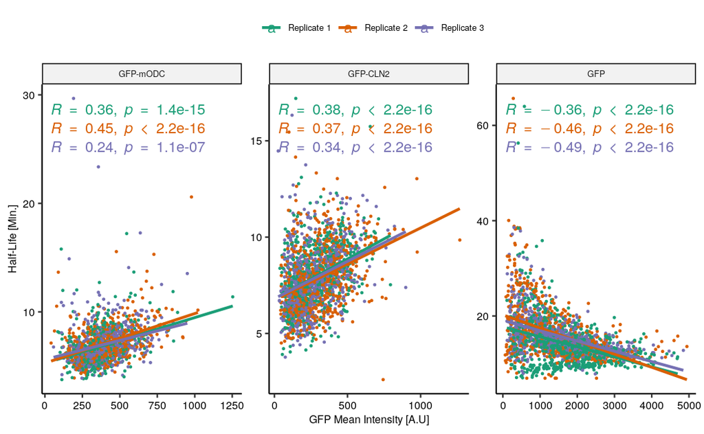

```r
gfpInt.pup1.rep1.plot <- fig2.df.mat %>%
  filter(!(degron %in% c("cln2","cln2.2","mODC","stable"))) %>%
  mutate(degron = case_when(degron %in% c("cln2.3","cln2.4") ~ "GFP-CLN2",
                            degron == "mODC.2" ~ "GFP-mODC",
                            degron %in% c("stable.2","stable.3") ~ "GFP"),
         degron = factor(degron , levels = c("GFP-mODC","GFP-CLN2", "GFP"))) %>%
  mutate(dapi.mean.bg.sub.puncta = ifelse(is.na(dapi.mean.bg.sub.puncta), 0, dapi.mean.bg.sub.puncta) ,
         rfp.mean.bg.sub.puncta = ifelse(is.na(rfp.mean.bg.sub.puncta), 0 , rfp.mean.bg.sub.puncta)) %>%
  ggplot(.,aes(x = gfp.mean.bg.af.sub.new, y = log(2)/dy, color = colony))+
  geom_point(size = 0.5)+
  geom_smooth(method = "lm", se = FALSE)+
  facet_wrap(~degron, scales = "free")+
  stat_cor()+
  theme_pubr()+
  theme(text = element_text(size = 8))+
  scale_color_brewer(name = NULL, palette = "Dark2")+
  ylab("Half-Life [Min.]")+
  xlab("GFP Mean Intensity [A.U]")

gfpInt.pup1.rep1.plot
```

binning gfp intensity

```r
fig2.df %>%
  mutate(degron = case_when(degron == "cln2.3" ~ "GFP-CLN2",
                            degron == "mODC.2" ~ "GFP-mODC",
                            degron == "stable.2" ~ "GFP"),
         degron = factor(degron , levels = c("GFP-mODC","GFP-CLN2", "GFP"))) %>%
  mutate(dapi.mean.bg.sub.puncta = ifelse(is.na(dapi.mean.bg.sub.puncta), 0, dapi.mean.bg.sub.puncta) ,
         rfp.mean.bg.sub.puncta = ifelse(is.na(rfp.mean.bg.sub.puncta), 0 , rfp.mean.bg.sub.puncta),
         elipe_shape = Elip_B/Elip_C,
         t.half = log(2)/dy) %>%
  split(list(.$degron, .$colony)) %>%
  map(function(a){
    a %>%
    mutate(gfp_bin = cut(gfp.mean.bg.af.sub.new, breaks = quantile(.$gfp.mean.bg.af.sub.new, probs = seq(0, 1, by = 0.2))))  %>%
      arrange(gfp_bin)
  }) %>% bind_rows() %>%

  ggplot(.,aes(x = gfp_bin, y = t.half, fill = colony))+
  geom_boxplot(outlier.size = 0.5)+
    facet_wrap(~degron, scales = "free")+
  theme(text = element_text(size = 8),
        axis.text.x = element_text(angle = 90))
```

#dapi distribution

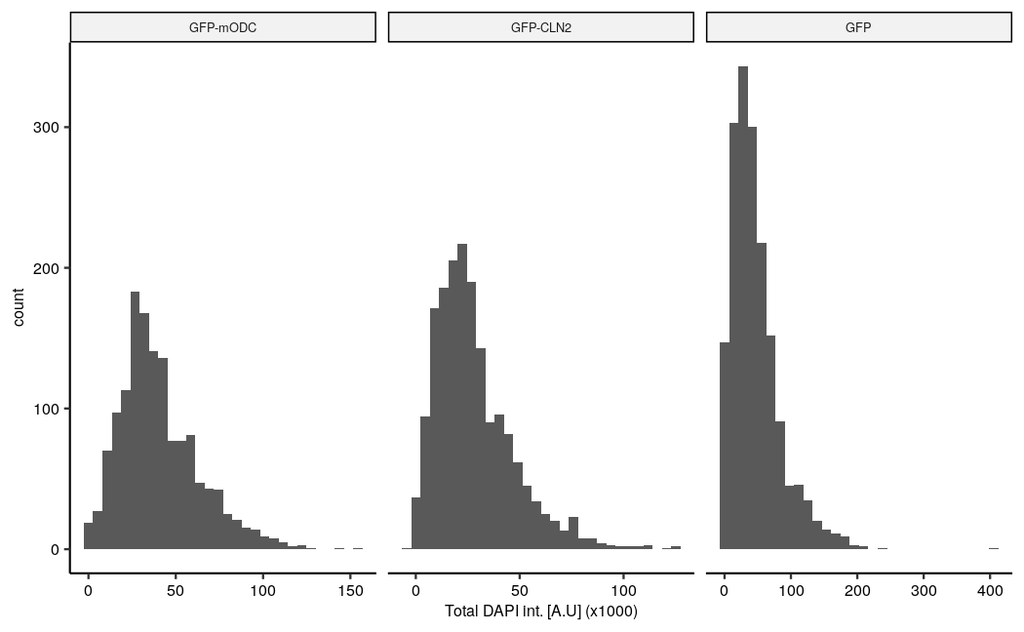

```r
dapi.dist
```

total dapi intensity vs dy

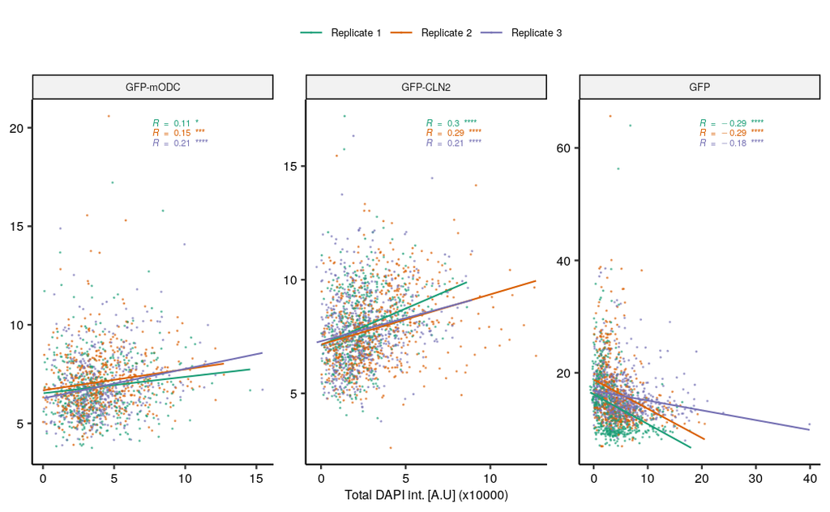

```r
dapiInt.pup1.rep1.plot <- fig2.df.mat %>%
  filter(!(degron %in% c("cln2","cln2.2","mODC","stable"))) %>%
  mutate(degron = case_when(degron %in% c("cln2.3","cln2.4") ~ "GFP-CLN2",
                            degron == "mODC.2" ~ "GFP-mODC",
                            degron %in% c("stable.2","stable.3") ~ "GFP"),
         degron = factor(degron , levels = c("GFP-mODC","GFP-CLN2", "GFP"))) %>%
  mutate(dapi.mean.bg.sub.puncta = ifelse(is.na(dapi.mean.bg.sub.puncta), 0, dapi.mean.bg.sub.puncta) ,
         rfp.mean.bg.sub.puncta = ifelse(is.na(rfp.mean.bg.sub.puncta), 0 , rfp.mean.bg.sub.puncta)) %>%
  filter(rfp.mean.bg.sub.puncta >0) %>%
  ggplot(.,aes(x = dapi.sum.bg.sub.puncta, y = log(2)/dy , color = colony))+
  geom_point(size = 0.1, alpha = 0.5)+
  geom_smooth(method = "lm", se = FALSE, size = 0.5)+
  facet_wrap(~degron, scales = "free")+
  stat_cor(size = 2, show.legend = FALSE, aes(label = paste(..r.label.., cut(..p..,
                                                                             breaks = c(-Inf, 0.0001, 0.001, 0.01, 0.05, Inf),
                                                                             labels = c("'****'", "'***'", "'**'", "'*'", "'ns'")),
                                                            sep = "~")),
           label.x.npc = "middle")+
  theme_pubr()+
  theme(text = element_text(size = 8),
        axis.title.y = element_blank())+
  scale_color_brewer(name = NULL, palette = "Dark2")+
  scale_x_continuous(labels = scales::label_number(scale = 1/10000))+
  xlab("Total DAPI int. [A.U] (x10000)")
  # ylab("Half-Life [Min.]")

dapiInt.pup1.rep1.plot
```

pup1-tDimer vs dy

```r
tDimerInt.pup1.rep1.plot <- fig2.df.all.2 %>%
  mutate(degron = case_when(degron == "cln2.3" ~ "GFP-CLN2",
                            degron == "mODC.2" ~ "GFP-mODC",
                            degron == "stable.2" ~ "GFP"),
         degron = factor(degron , levels = c("GFP-mODC","GFP-CLN2", "GFP"))) %>%
  mutate(dapi.mean.bg.sub.puncta = ifelse(is.na(dapi.mean.bg.sub.puncta), 0, dapi.mean.bg.sub.puncta) ,
         rfp.mean.bg.sub.puncta = ifelse(is.na(rfp.mean.bg.sub.puncta), 0 , rfp.mean.bg.sub.puncta)) %>%
  filter(rfp.mean.bg.sub.puncta >0, degron != "GFP") %>%
  ggplot(.,aes(x = rfp.mean.bg.sub.puncta, y = log(2)/dy, color = colony))+
  geom_point(size = 0.1, alpha = 0.5)+
  geom_smooth(method = "lm", se = FALSE, size = 0.5)+
  facet_wrap(~degron, scales = "free")+
  stat_cor(size = 2, show.legend = FALSE, aes(label = paste(..r.label.., cut(..p..,
                                              breaks = c(-Inf, 0.0001, 0.001, 0.01, 0.05, Inf),
                                              labels = c("'****'", "'***'", "'**'", "'*'", "'ns'")),
                            sep = "~")))+
  theme_pubr()+
  theme(text = element_text(size = 8),
        axis.title.y = element_blank())+
  scale_color_brewer(name = NULL, palette = "Dark2")+
  scale_x_continuous(labels = scales::label_number(scale = 1/100))+
  ylab("Half-Life [Min.]")+
  xlab("Pup1-tDimer Mean Intensity [A.U] (x100)")

tDimerInt.pup1.rep1.plot
```

binning by pup1-rfp

```r
corttest <- fig2.df %>%
  ungroup() %>%
  mutate(degron = case_when(degron == "cln2.3" ~ "GFP-CLN2",
                            degron == "mODC.2" ~ "GFP-mODC",
                            degron == "stable.2" ~ "GFP"),
         degron = factor(degron , levels = c("GFP-mODC","GFP-CLN2", "GFP"))) %>%
  mutate(dapi.mean.bg.sub.puncta = ifelse(is.na(dapi.mean.bg.sub.puncta), 0, dapi.mean.bg.sub.puncta) ,
         rfp.mean.bg.sub.puncta = ifelse(is.na(rfp.mean.bg.sub.puncta), 0 , rfp.mean.bg.sub.puncta),
         elipe_shape = Elip_B/Elip_C,
         t.half = log(2)/dy) %>%
    filter(rfp.mean.bg.sub.puncta > 0) %>%
  split(list(.$degron, .$colony)) %>%
  map(function(a){
    a %>%
    mutate(pup1_bin = cut(rfp.mean.bg.sub.puncta,
                          breaks = quantile(.$rfp.mean.bg.sub.puncta, probs = seq(0, 1, by = 0.2))))
  })

lapply(corttest, function(a){
  a %>%
    split(.$pup1_bin) %>%
    map(function(b){
      cor.test(x = b$t.half, y = b$rfp.mean.bg.sub.puncta, method = "pearson", alternative = "two.sided") %>%
        broom::tidy()
    }) %>%
    bind_rows(.id = "pup1_bin")
}) %>%
  bind_rows(.id = "test") %>%
  separate(col = test, into = c("degron","colony"), sep = "\\.") %>%
  # filter(p.value < 0.05) %>%
  arrange(degron) %>% filter(degron == "GFP-mODC")
```

#pup1 vs half lives in pup1-bins

```r
corttest.all.pup1 <- fig2.df.mat %>%
  ungroup() %>%
  mutate(degron = case_when(degron == "cln2.3" ~ "GFP-CLN2",
                            degron == "mODC.2" ~ "GFP-mODC",
                            degron == "stable.2" ~ "GFP"),
         degron = factor(degron , levels = c("GFP-mODC","GFP-CLN2", "GFP"))) %>%
  mutate(dapi.mean.bg.sub.puncta = ifelse(is.na(dapi.mean.bg.sub.puncta), 0, dapi.mean.bg.sub.puncta) ,
         rfp.mean.bg.sub.puncta = ifelse(is.na(rfp.mean.bg.sub.puncta), 0 , rfp.mean.bg.sub.puncta),
         elipe_shape = Elip_B/Elip_C,
         t.half = log(2)/dy) %>%
    filter(rfp.mean.bg.sub.puncta > 0) %>%
  split(list(.$degron, .$colony)) %>%
  map(function(a){
    a %>%
    mutate(pup1_bin = cut(rfp.mean.bg.sub.puncta,
                          breaks = quantile(.$rfp.mean.bg.sub.puncta, probs = seq(0, 1, by = 0.2))))
  })

lapply(corttest, function(a){
  a %>%
    split(.$pup1_bin) %>%
    map(function(b){
      cor.test(x = b$t.half, y = b$rfp.mean.bg.sub.puncta, method = "pearson", alternative = "two.sided") %>%
        broom::tidy()
    }) %>%
    bind_rows(.id = "pup1_bin")
}) %>%
  bind_rows(.id = "test") %>%
  separate(col = test, into = c("degron","colony"), sep = "\\.") %>%
  filter(p.value < 0.05) %>%
  arrange(degron) %>% filter(degron == "GFP-mODC")

lapply(corttest.all, function(a){
  a %>%
    split(.$pup1_bin) %>%
    map(function(b){
      cor.test(x = b$t.half, y = b$rfp.mean.bg.sub.puncta, method = "pearson", alternative = "two.sided") %>%
        broom::tidy()
    }) %>%
    bind_rows(.id = "pup1_bin")
}) %>%
  bind_rows(.id = "test") %>%
  separate(col = test, into = c("degron","colony"), sep = "\\.") %>%
  filter(p.value < 0.05) %>%
  arrange(degron) %>% filter(degron == "GFP-mODC")
```

```r
lapply(corttest.all, function(a){
  a %>%
      ggplot(.,aes(x = t.half, y = rfp.mean.bg.sub.puncta))+
        geom_point()+
        geom_smooth(method = "lm")+
        stat_cor()+
    facet_wrap(~pup1_bin, scales = "free")
})

lapply(corttest, function(a){
  a %>%
      ggplot(.,aes(x = t.half, y = rfp.mean.bg.sub.puncta))+
        geom_point()+
        geom_smooth(method = "lm")+
        stat_cor()+
    facet_wrap(~pup1_bin, scales = "free")+
    scale_x_log10()
})
```

#dapi vs half lives in dapi-bins

```r
corttest.all <- fig2.df.mat %>%
  ungroup() %>%
  filter(!(degron %in% c("cln2","cln2.2","mODC","stable"))) %>%
  # mutate(degron = case_when(degron %in% c("cln2.3","cln2.4") ~ "GFP-CLN2",
  #                           degron == "mODC.2" ~ "GFP-mODC",
  #                           degron %in% c("stable.2","stable.3") ~ "GFP"),
  #        degron = factor(degron , levels = c("GFP-mODC","GFP-CLN2", "GFP"))) %>%
  mutate(dapi.mean.bg.sub.puncta = ifelse(is.na(dapi.mean.bg.sub.puncta), 0, dapi.mean.bg.sub.puncta) ,
         rfp.mean.bg.sub.puncta = ifelse(is.na(rfp.mean.bg.sub.puncta), 0 , rfp.mean.bg.sub.puncta),
         elipe_shape = Elip_B/Elip_C,
         t.half = log(2)/dy) %>%
    filter(rfp.mean.bg.sub.puncta > 0,
           dapi.sum.bg.sub.puncta > 0) %>%
  split(list(.$degron)) %>%
  map(function(a){
    a %>%
    mutate(dapi_bin = cut(dapi.sum.bg.sub.puncta/10000,
                          breaks = quantile(.$dapi.sum.bg.sub.puncta/10000, probs = seq(0, 1, by = 0.1))),
           pup1_bin = cut(rfp.mean.bg.sub.puncta,
                          breaks = quantile(rfp.mean.bg.sub.puncta, probs = seq(0,1,by = 0.1))))
  })

map(corttest.all, function(a){
  a %>%
    filter(is.na(dapi_bin))
})
```

| cell.id | f | dy | dm | value | fevals | gevals | niter | convcode | kkt1 | kkt2 | xtime | degron | red | treatment | model | k | aic | exp.field | colony | gfp.mean.bg.af.sub.new | gfp.sum.bg.af.sub | area | area.puncta | BB_B | BB_C | Elip_B | Elip_C | no.of.voxels | pos.x | … |
| --- | --- | --- | --- | --- | --- | --- | --- | --- | --- | --- | --- | --- | --- | --- | --- | --- | --- | --- | --- | --- | --- | --- | --- | --- | --- | --- | --- | --- | --- | --- |
| 1000002268_20min_s6_cln2.3_pup1-rfp_none | NA | 0.07312582 | 1.260874 | 0.02347221 | 22 | 22 | NA | 0 | FALSE | TRUE | 1.797 | cln2.3 | pup1-rfp | none | dy.dm | 2 | -218.7637 | 20min_s6 | Replicate 2 | 182.5356 | 118282.9 | 1402.33 | NA | NA | NA | 13.9585 | 18.5538 | 648 | 813.002 | … |

| cell.id | f | dy | dm | value | fevals | gevals | niter | convcode | kkt1 | kkt2 | xtime | degron | red | treatment | model | k | aic | exp.field | colony | gfp.mean.bg.af.sub.new | gfp.sum.bg.af.sub | area | area.puncta | BB_B | BB_C | Elip_B | Elip_C | no.of.voxels | pos.x | … |
| --- | --- | --- | --- | --- | --- | --- | --- | --- | --- | --- | --- | --- | --- | --- | --- | --- | --- | --- | --- | --- | --- | --- | --- | --- | --- | --- | --- | --- | --- | --- |
| 1000001954_20min_s7_cln2.4_pup1-rfp_none | NA | 0.06980412 | 0.7665672 | 0.2022043 | 42 | 42 | NA | 0 | FALSE | TRUE | 3.03 | cln2.4 | pup1-rfp | none | dy.dm | 2 | -152.0064 | 20min_s7 | Replicate 3 | 426.2173 | 672568.3 | 3324.43 | 268.086 | NA | NA | 23.22 | 27.1217 | 1578 | 1049.86 | … |

| cell.id | f | dy | dm | value | fevals | gevals | niter | convcode | kkt1 | kkt2 | xtime | degron | red | treatment | model | k | aic | exp.field | colony | gfp.mean.bg.af.sub.new | gfp.sum.bg.af.sub | area | area.puncta | BB_B | BB_C | Elip_B | Elip_C | no.of.voxels | pos.x | … |
| --- | --- | --- | --- | --- | --- | --- | --- | --- | --- | --- | --- | --- | --- | --- | --- | --- | --- | --- | --- | --- | --- | --- | --- | --- | --- | --- | --- | --- | --- | --- |
| 1000002260_20min_s5_mODC.2_pup1-rfp_none | NA | 0.1368511 | 0.2233619 | 0.01393271 | 42 | 42 | NA | 0 | TRUE | TRUE | 3.297 | mODC.2 | pup1-rfp | none | dy.dm | 2 | -234.9326 | 20min_s5 | Replicate 2 | 336.6802 | 246112.9 | 1575.13 | NA | NA | NA | 16.8139 | 17.5481 | 731 | 47.0144 | … |

| cell.id | f | dy | dm | value | fevals | gevals | niter | convcode | kkt1 | kkt2 | xtime | degron | red | treatment | model | k | aic | exp.field | colony | gfp.mean.bg.af.sub.new | gfp.sum.bg.af.sub | area | area.puncta | BB_B | BB_C | Elip_B | Elip_C | no.of.voxels | pos.x | … |
| --- | --- | --- | --- | --- | --- | --- | --- | --- | --- | --- | --- | --- | --- | --- | --- | --- | --- | --- | --- | --- | --- | --- | --- | --- | --- | --- | --- | --- | --- | --- |
| 1000002125_20min_s7_stable.2_pup1-rfp_none | NA | 0.03942551 | 114.6828 | 0.05719087 | 46 | 46 | NA | 0 | FALSE | FALSE | 3.423 | stable.2 | pup1-rfp | none | dy.dm | 2 | -191.1558 | 20min_s7 | Replicate 3 | 1141.776 | 339108.8 | 663.52 | NA | NA | NA | 9.93037 | 11.9722 | 297 | 1122.68 | … |

| cell.id | f | dy | dm | value | fevals | gevals | niter | convcode | kkt1 | kkt2 | xtime | degron | red | treatment | model | k | aic | exp.field | colony | gfp.mean.bg.af.sub.new | gfp.sum.bg.af.sub | area | area.puncta | BB_B | BB_C | Elip_B | Elip_C | no.of.voxels | pos.x | … |
| --- | --- | --- | --- | --- | --- | --- | --- | --- | --- | --- | --- | --- | --- | --- | --- | --- | --- | --- | --- | --- | --- | --- | --- | --- | --- | --- | --- | --- | --- | --- |
| 1000002365_20min_s3_stable.3_pup1-rfp_none | NA | 0.05271769 | 139.1309 | 0.006981854 | 57 | 57 | NA | 0 | FALSE | FALSE | 3.693 | stable.3 | pup1-rfp | none | dy.dm | 2 | -256.3513 | 20min_s3 | Replicate 1 | 1864.836 | 1831269 | 2095.41 | 290.484 | NA | NA | 18.7481 | 20.8925 | 982 | 530.774 | … |

```
NA
```

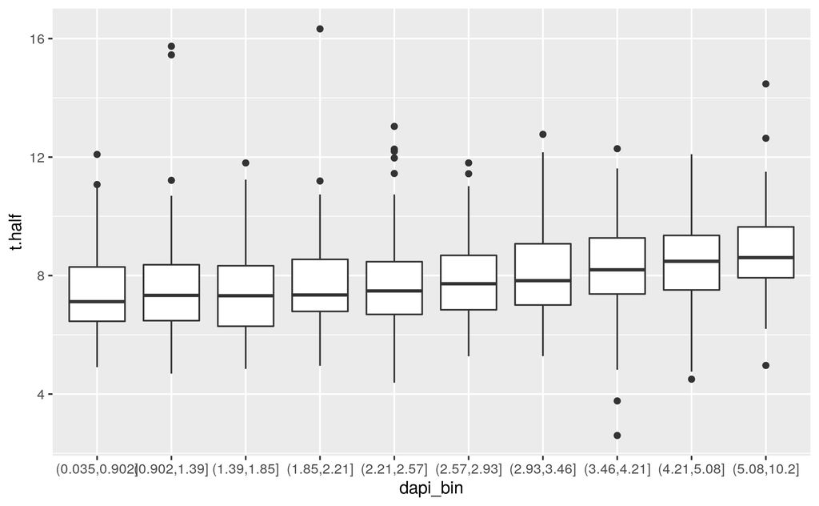

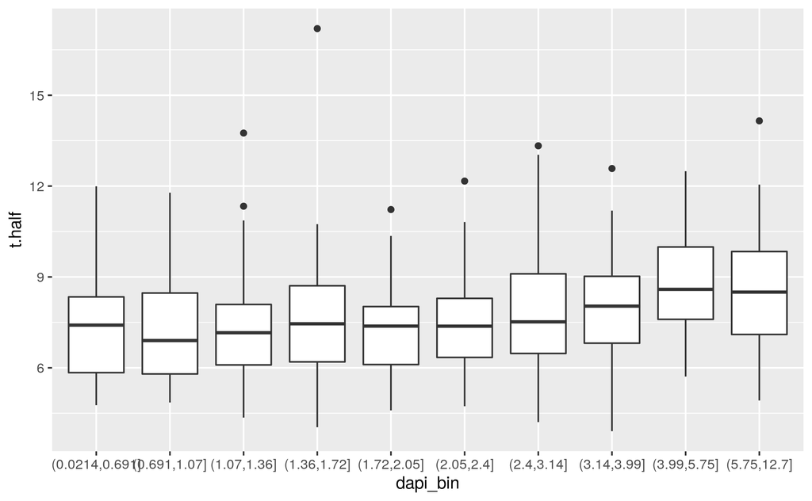

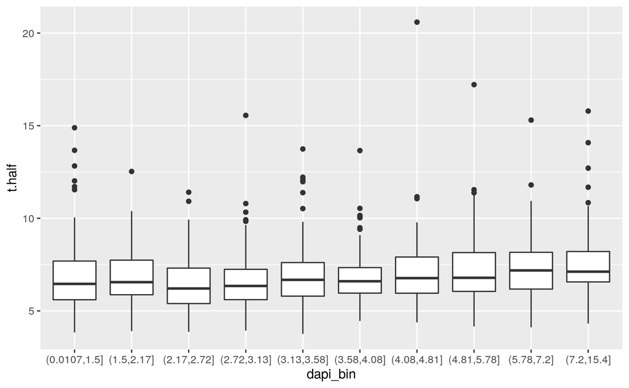

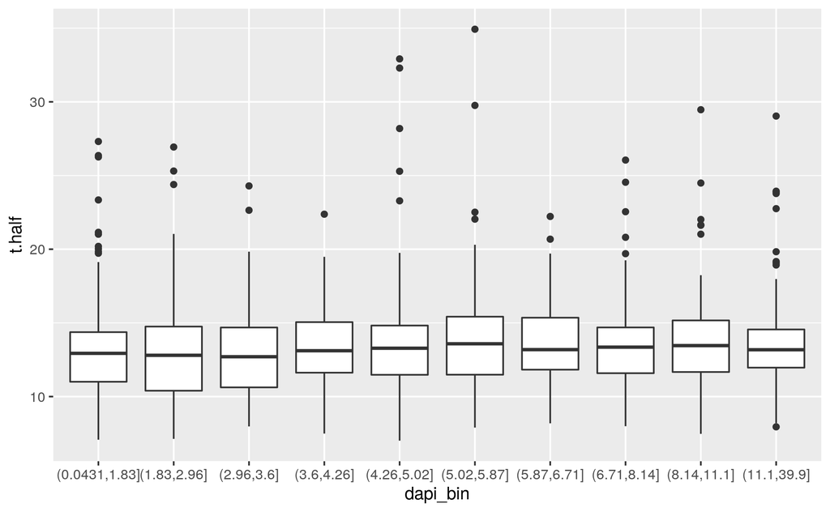

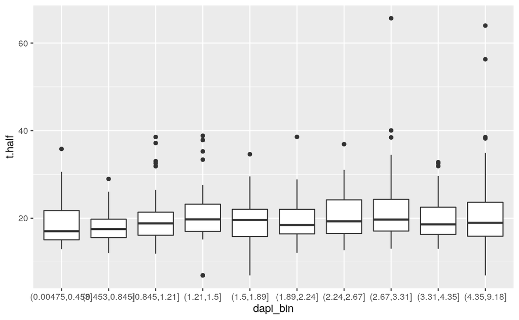

```r
lapply(corttest.all, function(a){
  a %>%
    filter(!is.na(dapi_bin)) %>%
      ggplot(.,aes(y = t.half, x = dapi_bin))+
        geom_boxplot()
})
```

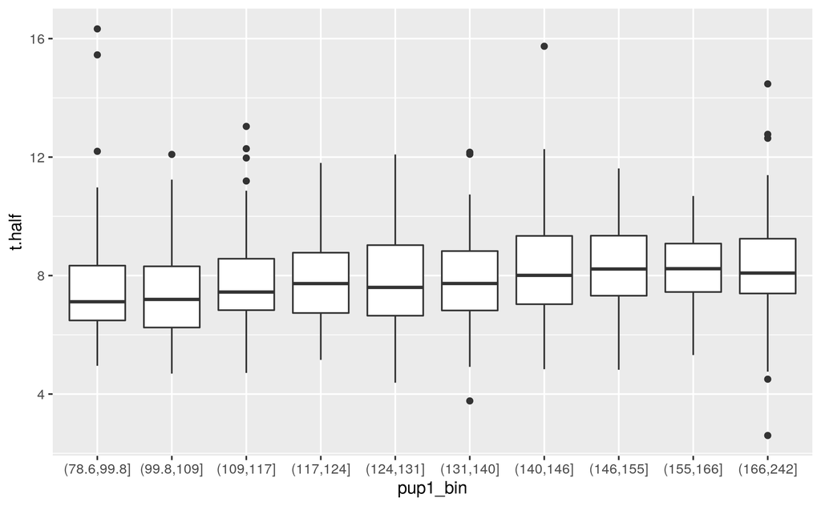

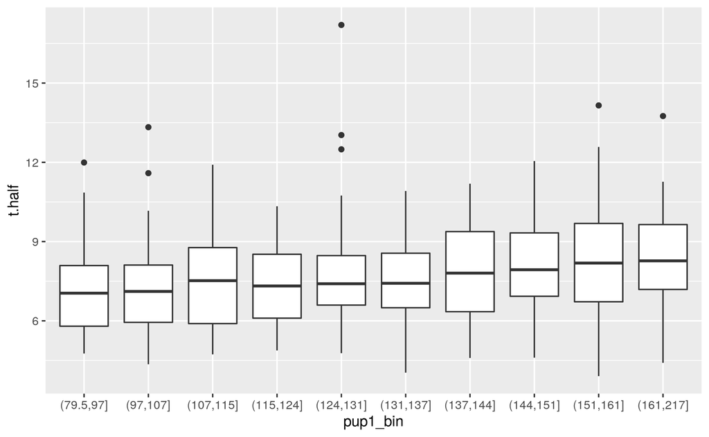

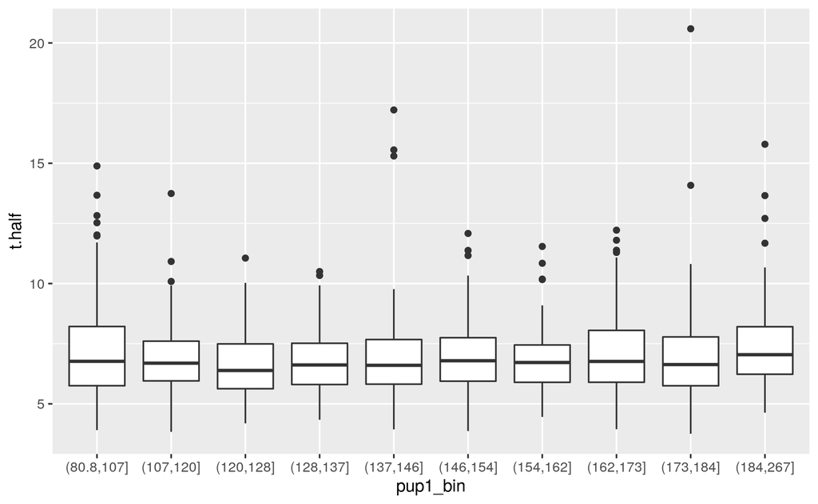

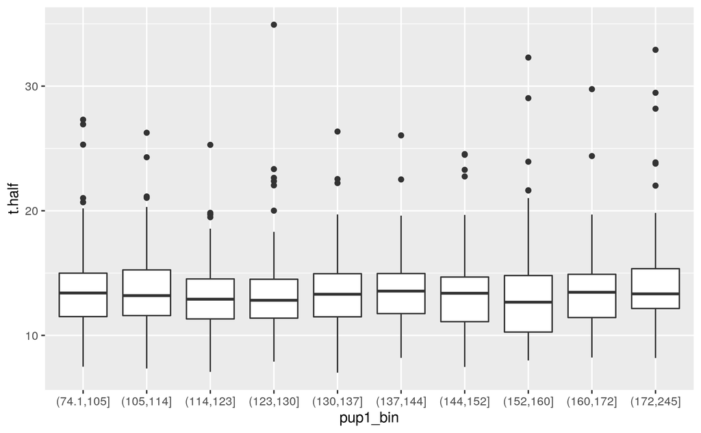

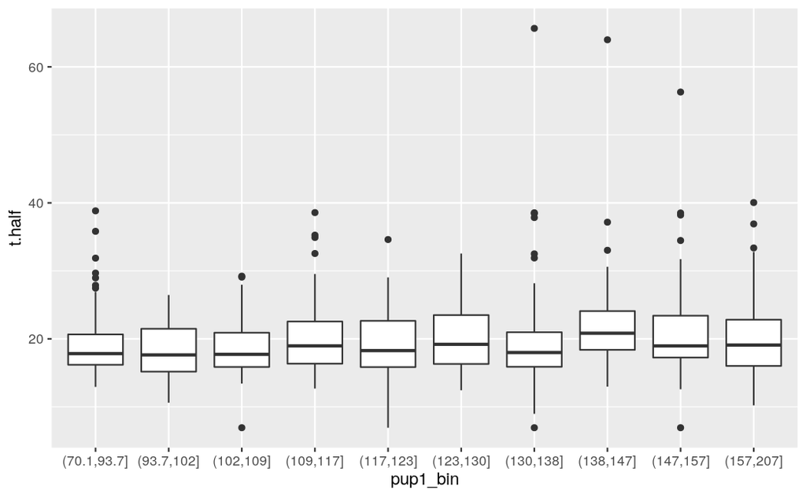

```r
lapply(corttest.all, function(a){
  a %>%
    filter(!is.na(pup1_bin)) %>%
      ggplot(.,aes(y = t.half, x = pup1_bin))+
        geom_boxplot()
})
```

#for cln2 cells divide cells into 1c vs 2c cells based on DAPI staining cln2

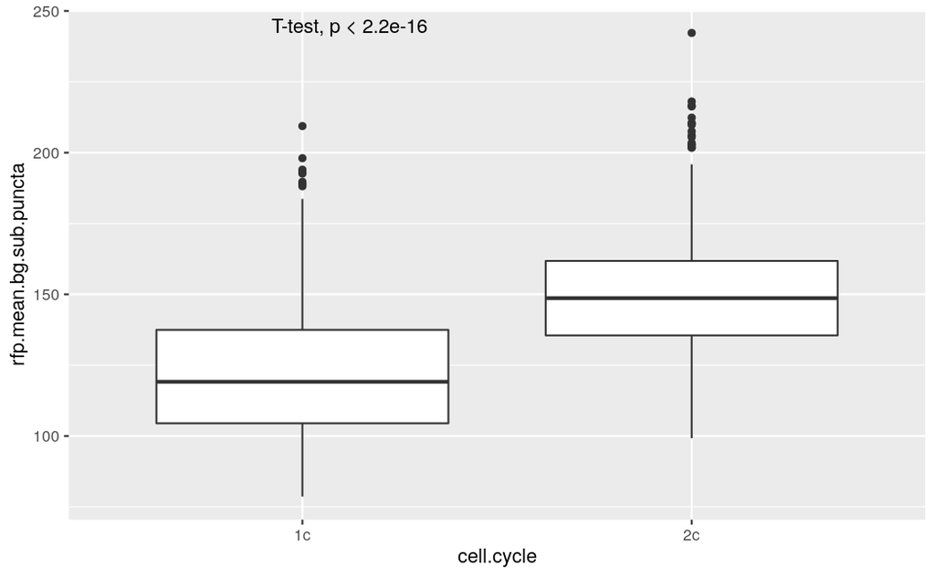

#designating cells as high and low DNA content based on the median of the total DAPI intensity #and checking if the variance in t-hallf between the low and high dapi content is significantly different

| degron | estimate | num.df | den.df | statistic | p.value | conf.low | conf.high | method | alternative | cell.cycle |
| --- | --- | --- | --- | --- | --- | --- | --- | --- | --- | --- |
| GFP-mODC | 0.8867615 | 712 | 712 | 0.8867615 | F-test, p = 0.1091 | 0.7655181 | 1.027208 | F test to compare two variances | two.sided | low |
| GFP-CLN2 | 1.0678640 | 884 | 883 | 1.0678640 | F-test, p = 0.3293 | 0.9358444 | 1.218501 | F test to compare two variances | two.sided | low |
| GFP | 1.4479426 | 870 | 869 | 1.4479426 | F-test, p = 5.327e-08 | 1.2675902 | 1.653947 | F test to compare two variances | two.sided | low |

##mODC

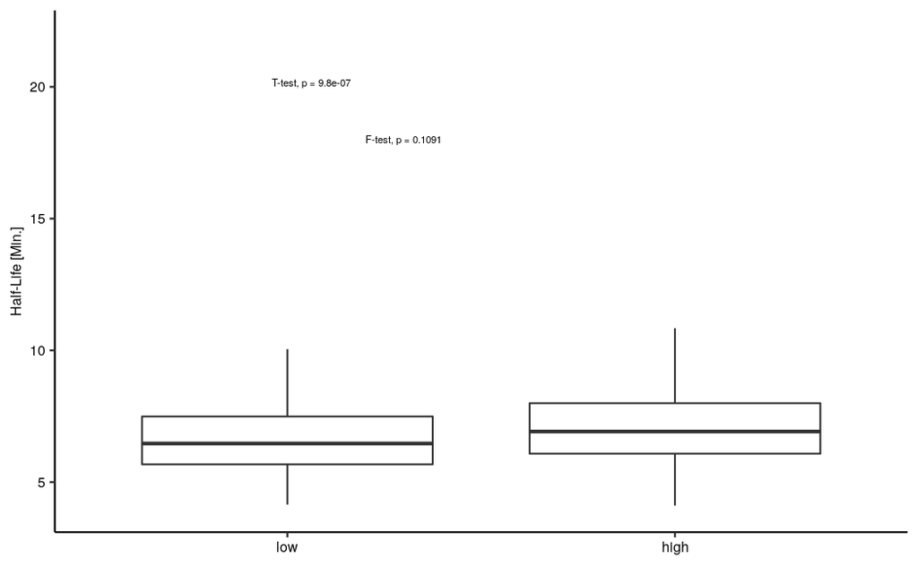

```r
modc.dapi.half.plt <- fig2.dapi.df %>%
  filter(degron == "GFP-mODC") %>%
  ungroup() %>%
  ggplot(.,aes(x = cell.cycle, y = t.half))+
  geom_boxplot(outlier.shape = NA)+
  # geom_jitter(size = 0.2, width = 0.3, color = "gray50")+
  geom_text(data = dapi.half.var %>%
              filter(degron == "GFP-mODC") , aes(x = 1.3, y = 18, label = p.value),
            size = 2)+
  stat_compare_means(method = "t.test", size = 2 , label.x = 1, label.y = 20)+
  # facet_wrap(~colony,scales = "free")+
  ylim(4,22)+
  theme_pubr()+
  ylab("Half-Life [Min.]")+
  theme(text = element_text(size = 8),
        axis.title.x =  element_blank())
modc.dapi.half.plt
```

##Stable GFP

[figure not shown]

```r
stable.dapi.half.plt
```

##CLN2

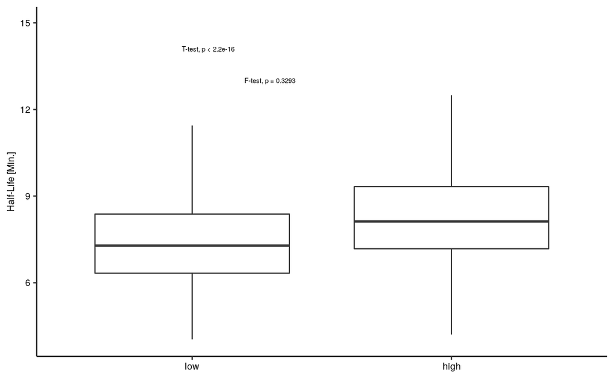

```r
cln2.dapi.half.plt <- fig2.dapi.df %>%
  filter(degron == "GFP-CLN2") %>%
  ungroup() %>%
  ggplot(.,aes(x = cell.cycle, y = t.half))+
  geom_boxplot(outlier.shape = NA)+
  # geom_jitter(size = 0.2, width = 0.3, color = "gray50")+
  geom_text(data = dapi.half.var %>%
              filter(degron == "GFP-CLN2") , aes(x = 1.3, y = 13, label = p.value),
            size = 2)+
  stat_compare_means(method = "t.test", size = 2 , label.x = 1, label.y = 14)+
  # facet_wrap(~colony,scales = "free")+
  ylim(4,15)+
  theme_pubr()+
  ylab("Half-Life [Min.]")+
  theme(text = element_text(size = 8),
        axis.title.x =  element_blank())

cln2.dapi.half.plt
```

```r
fig2.df %>%
  mutate(dapi.mean.bg.sub.puncta = ifelse(is.na(dapi.mean.bg.sub.puncta), 0, dapi.mean.bg.sub.puncta) ,
         rfp.mean.bg.sub.puncta = ifelse(is.na(rfp.mean.bg.sub.puncta), 0 , rfp.mean.bg.sub.puncta),
         elipe_shape = Elip_B/Elip_C,
         t.half = log(2)/dy) %>%
  filter(degron == "cln2.3", rfp.mean.bg.sub.puncta > 0) %>%
  ungroup() %>%
  mutate(cell.cycle = ifelse(dapi.sum.bg.sub.puncta > 50000, "2c","1c")) %>%
  group_by(colony, cell.cycle) %>%
  summarise(cv.half = sd(t.half)/mean(t.half),
            cv.pup1 = sd(rfp.mean.bg.sub.puncta)/mean(rfp.mean.bg.sub.puncta),
            fano.pup1 = var(rfp.mean.bg.sub.puncta)/mean(rfp.mean.bg.sub.puncta))


fig2.df %>%
  mutate(dapi.mean.bg.sub.puncta = ifelse(is.na(dapi.mean.bg.sub.puncta), 0, dapi.mean.bg.sub.puncta) ,
         rfp.mean.bg.sub.puncta = ifelse(is.na(rfp.mean.bg.sub.puncta), 0 , rfp.mean.bg.sub.puncta),
         elipe_shape = Elip_B/Elip_C,
         t.half = log(2)/dy) %>%
  filter(degron == "mODC.2", rfp.mean.bg.sub.puncta > 0) %>%
  ungroup() %>%
  mutate(cell.cycle = ifelse(dapi.sum.bg.sub.puncta > 50000, "2c","1c")) %>%
  group_by(colony, cell.cycle) %>%
  summarise(cv.half = sd(t.half)/mean(t.half),
            cv.pup1 = sd(rfp.mean.bg.sub.puncta)/mean(rfp.mean.bg.sub.puncta),
            fano.pup1 = var(rfp.mean.bg.sub.puncta)/mean(rfp.mean.bg.sub.puncta))

fig2.df %>%
  mutate(dapi.mean.bg.sub.puncta = ifelse(is.na(dapi.mean.bg.sub.puncta), 0, dapi.mean.bg.sub.puncta) ,
         rfp.mean.bg.sub.puncta = ifelse(is.na(rfp.mean.bg.sub.puncta), 0 , rfp.mean.bg.sub.puncta),
         elipe_shape = Elip_B/Elip_C,
         t.half = log(2)/dy) %>%
  filter(degron == "stable.2", rfp.mean.bg.sub.puncta > 0) %>%
  ungroup() %>%
  mutate(cell.cycle = ifelse(dapi.sum.bg.sub.puncta > 90000, "2c","1c")) %>%
  group_by(colony, cell.cycle) %>%
  summarise(cv.half = sd(t.half)/mean(t.half),
            cv.pup1 = sd(rfp.mean.bg.sub.puncta)/mean(rfp.mean.bg.sub.puncta),
            fano.pup1 = var(rfp.mean.bg.sub.puncta)/mean(rfp.mean.bg.sub.puncta))
```

```r
top.sec <- (area.pup1.rep1.plot|dapiInt.pup1.rep1.plot|tDimerInt.pup1.rep1.plot)+plot_layout(guides = "collect")&theme(legend.position = "top")
bottom.sec.1 <- cln2.dapi.half.plt
bottom.sec.2 <- modc.dapi.half.plt

fig2.plt <- (top.sec/(bottom.sec.1|bottom.sec.2))+
  plot_layout(widths = c(0.6, 0.6))+
  plot_annotation(tag_levels = "A")

fig2.plt
```

```r
ggsave(plot = fig2.plt , filename = "fig2.pdf", path = "~/plots/paper1/figures/fig_2/", width = 8, height = 5)
ggsave(plot = fig2.plt , filename = "fig2.pdf", path = "~/plots/paper1/figures/fig_2/", width = 8, height = 5)
```

#suplemental figure 3